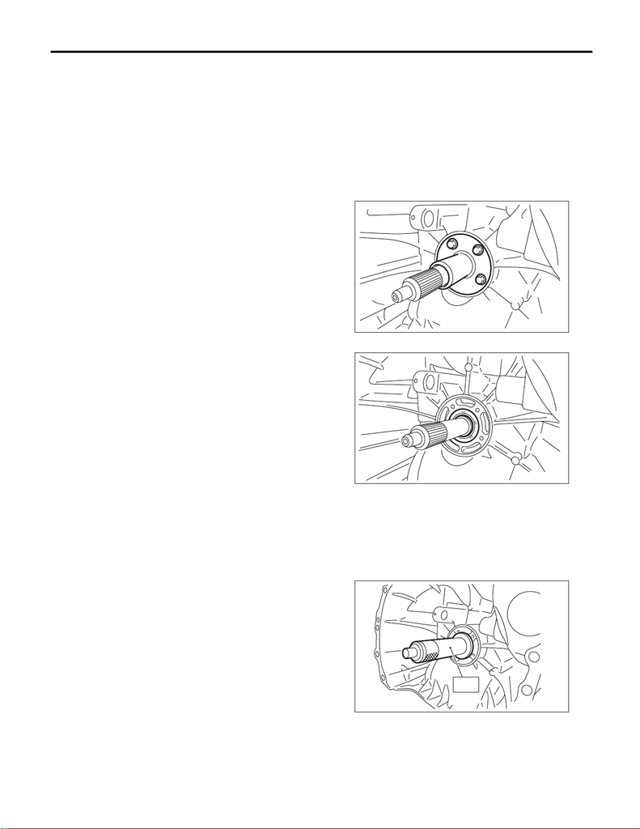

Clutch Housing

MANUAL TRANSMISSION AND DIFFERENTIAL

25.Clutch Housing

A: REMOVAL

1) Remove the manual transmission assembly

from the vehicle. <Ref. to 6MT(TY85)-31, REMOV-

AL, Manual Transmission Assembly.>

2) Prepare the transmission for overhaul. <Ref. to

6MT(TY85)-38, Preparation for Overhaul.>

3) Remove the neutral position switch, back-up

light switch and harness. <Ref. to 6MT(TY85)-41,

REMOVAL, Neutral Position Switch.> <Ref. to

6MT(TY85)-40, REMOVAL, Back-up Light

Switch.>

4) Remove the extension case. <Ref. to

6MT(TY85)-42, REMOVAL, Extension Case.>

5) Remove the transfer driven gear. <Ref. to

6MT(TY85)-54, REMOVAL, Transfer Driven

Gear.>

6) Remove the center differential. <Ref. to

6MT(TY85)-56, REMOVAL, Center Differential.>

7) Remove the transmission case. <Ref. to

6MT(TY85)-57, REMOVAL, Transmission Case.>

8) Remove the individual gear assemblies. <Ref. to

6MT(TY85)-63, REMOVAL, Main Shaft Assem-

bly.>

9) Remove the drive pinion shaft assembly. <Ref.

to 6MT(TY85)-92, REMOVAL, Drive Pinion Shaft

Assembly.>

10) Remove the front differential assembly. <Ref.

to 6MT(TY85)-99, REMOVAL, Front Differential

Assembly.>

B: INSTALLATION

1) Install the pitching stopper bracket.

Tightening torque:

41 N·m (4.2 kgf-m, 30.2 ft-lb)

2) Install the front differential assembly. <Ref. to

6MT(TY85)-100, INSTALLATION, Front Differen-

tial Assembly.>

3) Install the drive pinion shaft assembly. <Ref. to

6MT(TY85)-92, INSTALLATION, Drive Pinion

Shaft Assembly.>

4) Install the individual gear assemblies all at once.

<Ref. to 6MT(TY85)-64, INSTALLATION, Main

Shaft Assembly.>

5) Install the transmission case. <Ref. to

6MT(TY85)-59, INSTALLATION, Transmission

Case.>

6) Install the center differential. <Ref. to

6MT(TY85)-56, INSTALLATION, Center Differen-

tial.>

7) Install the transfer driven gear. <Ref. to

6MT(TY85)-54, INSTALLATION, Transfer Driven

Gear.>

8) Install the extension case. <Ref. to 6MT(TY85)-

42, INSTALLATION, Extension Case.>

9) Install the neutral position switch, back-up light

switch and harness. <Ref. to 6MT(TY85)-41, IN-

STALLATION, Neutral Position Switch.> <Ref. to

6MT(TY85)-40, INSTALLATION, Back-up Light

Switch.>

10) Install the manual transmission assembly to the

vehicle. <Ref. to 6MT(TY85)-33, INSTALLATION,

Manual Transmission Assembly.>

C: DISASSEMBLY

1) Remove the clutch release bearing guide.

2) Remove the oil seal.

D: ASSEMBLY

1) Attach the oil seal to the clutch housing, being

careful not to damage the seal.

NOTE:

Use a new oil seal.

ST 18657AA020 OIL SEAL INSTALLER

2) Install the clutch release bearing guide.

Tightening torque:

6.4 N·m (0.7 kgf-m, 4.7 ft-lb)

MT-01383

MT-01381

MT-01382

ST

[figure not shown]

Clutch Housing

MANUAL TRANSMISSION AND DIFFERENTIAL

E: INSPECTION

1) Check to make sure there is no damage or

cracks on the clutch housing. If there is excessive

damage, replace the clutch housing.

2) Inspect the clutch housing for transmission gear

oil leakage. If any oil leaks are found, repair or re-

place the applicable part.